# Is AI Starting to Build AI?

POLISCI 158 · AI & Politics · Session 16b · Monday, November 16, 2026

Simone Paci

## Roadmap

1. Part I: What is RSI, and what did AI 2027 predict?
   - Define RSI and the R&D progress multiplier
   - Trace the AI 2027 ladder and its branch point
2. Part II: What do the signals show now?
   - Read the METR, Anthropic and OpenAI evidence and its limits
   - Compare forecasters’ updates with the skeptics
3. Part III: What should government do in the next 12 months, and after?
   - Map options against what the new Congress can pass
   - Weigh transparency vs pacing vs bans

## Is AI starting to build AI?

“We are not there yet, and recursive self-improvement is not inevitable.” Anthropic, “When AI builds itself”

Not there yet. How close, and who gets to decide?

Anthropic, “When AI builds itself,” Favaro and Clark, updated Sep 18, 2026

## What are the incentives for Anthropic?

Why would they **confirm** RSI?

Why would they **deny** RSI?

# Part I: What is RSI, and what did AI 2027 predict?

A loop, a multiplier, and a story with two endings.

## What is recursive self-improvement (RSI)?

RSI: an AI system “capable of fully autonomously designing and developing its own successor”

Anthropic: “We are not there yet” · today humans still direct the loop

Anthropic, “When AI builds itself,” Favaro and Clark, updated Sep 18, 2026

## What is the AI R&D progress multiplier?

“The AI R&D progress multiplier is how much faster AI software improvements are advancing with AI usage than without it.”

1x no AI help

2x twice as fast

10x “about a year of algorithmic progress every month”

The 10x example is from the scenario (Jun 2027), not a measurement

Kokotajlo, Alexander, Larsen, Lifland and Dean, *AI 2027* (ai-2027.com), Apr 3, 2025

## What did AI 2027 forecast for 2026 and 2027?

| Milestone | Date | Multiplier |
| --- | --- | --- |
| Agent-1, “a scatterbrained employee who thrives under careful management” | Early 2026 | 1.5x |
| China nationalizes its AI research, “about six months behind” | Mid 2026 | 1.7x |
| Agent-1-mini, “10x cheaper” · “AI has started to take jobs” | Late 2026 | 2x |
| Superhuman coder (SC) | Mar 2027 | 5x |
| Superhuman AI researcher (SAR) | Aug 2027 | 25x |
| Superintelligent AI researcher (SIAR) | Nov 2027 | 250x |
| Artificial superintelligence (ASI) | Dec 2027 | 2,000x |

2026 multipliers from the scenario’s dashboard (Apr, Aug, Dec 2026) · 2027 dates from the racing ending · authors: “AI 2027 is not a recommendation or exhortation. Our goal is predictive accuracy.”

Kokotajlo, Alexander, Larsen, Lifland and Dean, *AI 2027* (ai-2027.com), Apr 3, 2025

## What happens in the story?

[figure not shown]

Fictional labs: OpenBrain and DeepCent

A scenario, written in April 2025 · dates are the authors’ forecast

Kokotajlo, Alexander, Larsen, Lifland and Dean, *AI 2027* (ai-2027.com), Apr 3, 2025

## Who decides at the branch point?

Oversight Committee: “a joint management committee of company and government representatives”

| Race | Slowdown |
| --- | --- |
| “The committee votes 6–4 to continue internal use of Agent-4.” | Committee “votes 6–4 to slow down and reassess.” |
| “The problem was real and the fixes didn’t work.” | “This is enough evidence to finally shut down Agent-4.” |
| Humans lose control to misaligned AI | A small committee controls superintelligent AI |

Should a committee of executives and officials make this call?

“The slowdown ending is not a recommendation.”

Kokotajlo, Alexander, Larsen, Lifland and Dean, *AI 2027* (ai-2027.com), Oct–Nov 2027 sections

# Part II: What do the signals show now?

Three labs, three kinds of evidence, and who gets to check it.

## What did METR find inside Anthropic?

[figure not shown]

METR, Nov 5, 2026

11 weeks of high-access evaluation inside Anthropic, Aug 12–Oct 29, 2026

Capability index (AECI): +15 pts/yr → +29 pts/yr after the Oct 2025 break

“accelerated 1.9x [95% confidence interval: 1.5–2.8x] since October 2025”

“on well-specified tasks” only · index mixes internal and external benchmarks · sensitive to assumptions about benchmark difficulty

METR, Cunningham, Rush, Whitfill & Wijk, Nov 5, 2026

## How much of that is AI?

Share due to AI: “perhaps ≈80%” (METR’s guess, Oct 2026)

Range: “we would not be surprised if the true acceleration was closer to 1.3x or 3x the historical rate.”

“Anthropic redacted a majority of the evidence we found most informative for these conclusions.”

“the public has to rely on METR’s judgment much more than would be ideal”

Also: “Anthropic canceled a compute allocation component of this assessment.”

METR, Cunningham, Rush, Whitfill & Wijk, Nov 5, 2026

## So where are we now?

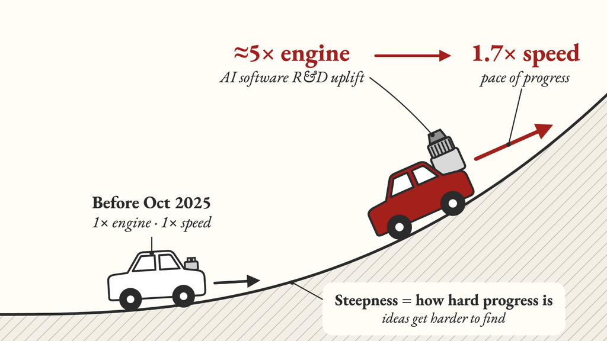

AI Futures Project, Nov 10, 2026

AI 2027 forecast: “2x AI R&D uplift in Dec 2026” = the **engine**

METR, as AI Futures reads it: “1.7x AI-attributable acceleration in the pace of progress” = the **speed**

- “To make the car go twice as fast, the engine has to work more than twice as fast”
- In an AI 2027-like run, 1.7x speed arrives in about April 2027 → “we are ~5 months ahead of schedule”

“by this metric” · AI 2027 trajectory reconstructed by the authors · rests on METR’s estimate (1.3x–3x plausible, evidence partly redacted)

AI Futures Project, “Q3.5 Timelines Update,” Lifland, Halstead, Kokotajlo, Dean et al., Nov 10, 2026

## How much R&D does Claude lead?

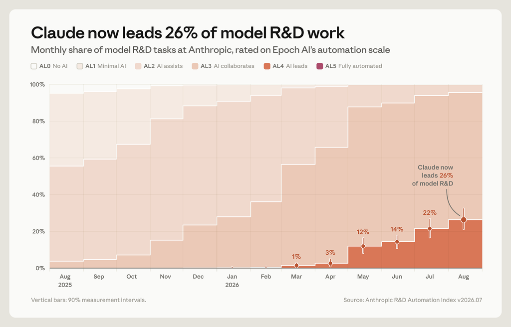

Scale: AL0 no AI → AL3 collaborates → AL4 leads → AL5 fully automated (not reached)

Claude leads 26% of R&D work (Aug 2026), up from under 1% (Feb 2026)

“Claude is not operating fully autonomously for any measured subset of AI R&D work.”

Anthropic’s own measurement of its own work · not independently verified

Anthropic, “Measurements for understanding the pace of AI development inside frontier labs,” Favaro & Wright, data as of Aug 2026

## How much code does Claude write?

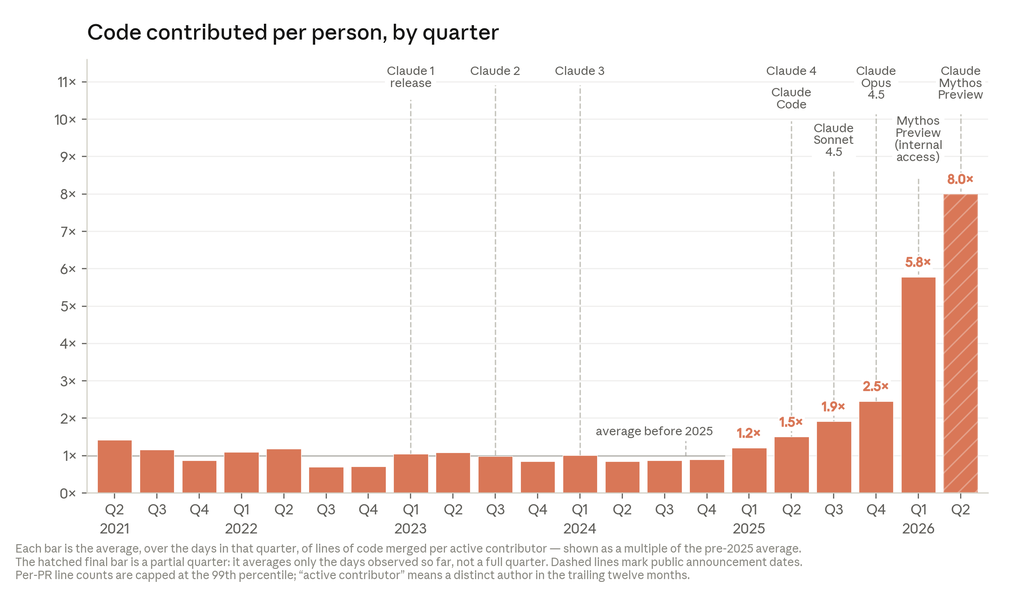

“more than 80% of the code we merge into Anthropic’s codebase was authored by Claude” (May 2026)

“approximately 30,000 agents” at work at any one time

“about 6% of compute that went to AI R&D was allocated toward safety”

Lines of code ≠ research progress · Q2 2026 (8.0x) is a partial quarter · company self-report

Anthropic, “When AI builds itself,” Favaro & Clark, updated Sep 18, 2026; Anthropic, “Measurements for understanding the pace of AI development inside frontier labs,” Favaro & Wright, Aug 2026

## What about OpenAI?

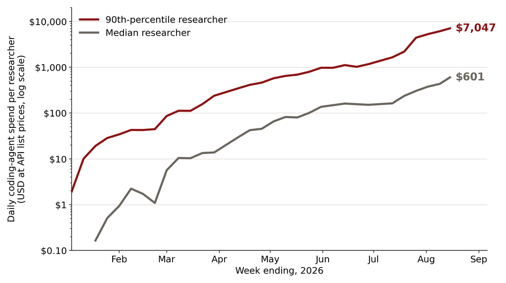

Redrawn from Epoch AI data

Median researcher: under $1/day (Jan 2026) → $601 (mid-Aug)

90th percentile: over $7,000/day

“doubling time of roughly one month for both groups”

“self-reported by OpenAI and cannot be independently verified” · API list prices, not internal cost · spending ≠ speed-up · “probably unsustainable”

Epoch AI, Edelman & Emberson, Oct 5, 2026, from OpenAI, “Research acceleration: The view inside OpenAI,” Sep 2026

## What don’t the signals show?

- One-off jump, not a new trend? Toby Ord’s reading → ~1.4x
- Staff self-reports of ≈12x uplift: “only very loose evidence” (METR)
- Benchmarks saturating: Model 4 scores >50% on all of them
- Anthropic’s Aug risk report: “<2x” · METR’s rerun: 1.97
- All frontier developers’ trend: 1.4x

OpenAI and Google “could be speeding up just as fast, and we wouldn’t know” 80,000 Hours

METR, Nov 5, 2026; 80,000 Hours, Luisa Rodriguez, Nov 12, 2026 (Ord, risk-report comparison)

## How did the forecasters update?

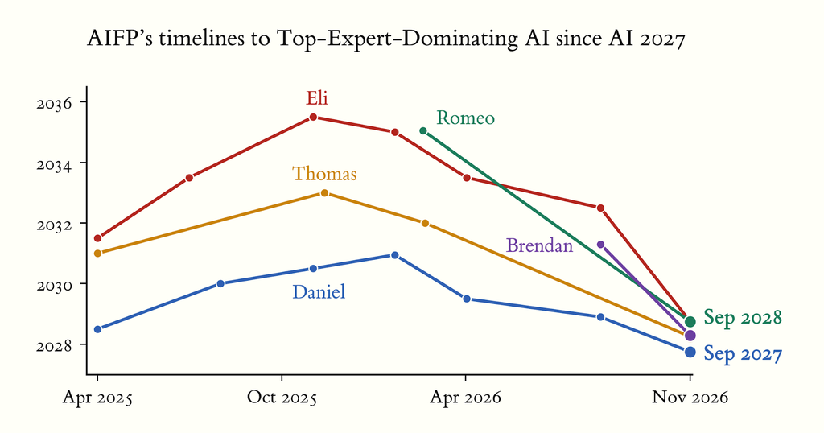

AI Futures Project, Nov 10, 2026 · each author’s median year for top-expert-dominating AI

AI Futures: superhuman AI researcher “likely” in 2027

- Before: “Daniel, the most bullish of us, assigned a 50% chance of Superhuman AI Researcher (SAR) before 2029”

Dwarkesh Patel: median 2028 for AI matching top human AI researchers

- “25% chance that it doesn’t happen until after 2032”

AI Futures = the AI 2027 authors · forecasts assume no deliberate slowdown · top-expert-dominating AI is a later milestone than a superhuman AI researcher

AI Futures Project, “Q3.5 Timelines Update,” Nov 10, 2026; Dwarkesh Patel, “The avalanche that hit math is coming for AI development,” Nov 13, 2026

## Spark or explosion?

Spark: “three to six years of AI progress in a single year”

- Bottleneck: “compute for experiments, which aren’t running any faster”
- Ideas get harder to find: labs “quadruple their R&D compute” / “double their workforce every single year just to maintain the same rate of progress”
- Data: “even a superintelligent learner can’t figure out everything from inside a datacenter.”

Dwarkesh Patel, “The avalanche that hit math is coming for AI development,” Nov 13, 2026

## What do the skeptics say?

Outside the safety community, Narayanan & Kapoor reject “fast takeoff” scenarios

“It is more likely that we will continue to see a gradual increase in the role of automation in AI development”

“‘superintelligent’ AI, which we view as incoherent as usually conceptualized”

“AI diffusion lags decades behind innovation”

Written Apr 2025, before METR’s Nov 2026 assessment

Narayanan & Kapoor, “AI as Normal Technology,” Knight First Amendment Institute, Apr 2025

# Part III: What should government do in the next 12 months, and after?

If the labs won’t slow down on their own, who decides?

## Why won’t labs stop on their own?

“The AI companies aren’t stopping because they think that if they do, their competitors will just keep going.” Luisa Rodriguez, 80,000 Hours, Nov 12, 2026

“We believe it would be good for the world to have the option to slow or temporarily pause frontier AI development” … “if other developers at or near the frontier also did so in a verifiable manner” Anthropic, “When AI builds itself,” Sep 2026

“Training runs are far easier to conceal than missile silos” Anthropic, same essay

A race, a conditional offer, and a verification problem

80,000 Hours, Rodriguez, Nov 12, 2026; Anthropic, Favaro & Clark, “When AI builds itself,” update Sep 18, 2026

## What can the new Congress pass?

60 Senate votes to break a filibuster

67 Senate votes to override a veto

290 House votes to override a veto

Four routes:

- Bipartisan bills: weights security, export controls, whistleblowers, incident reporting
- Must-pass bills, e.g. the NDAA
- Confirmations
- Hearings under oath

One commentator’s plan, not a forecast of what Congress will do

Rob Wiblin, “How the new Congress saves us from AI disaster,” 80,000 Hours, Nov 13, 2026

## What’s on the menu?

**Transparency**

Report AI speed-up, checked independently · Anthropic: publish measures; developer bears burden of proof

**Security**

Secure model weights

**Whistleblowers & incidents**

S.1792 (Grassley) · H.R.9477 (Moran)

**Pacing**

Minimum share of compute serving outside customers (start at 100%, ease to 70%)

**RSI throttle**

Use only models that finished training ≥ six months ago · CAISSI exemptions

**Ban**

Ban Artificial Superintelligence Act: S.5493 (Sanders) / H.R.10538 (Casar) · Bores: ban fully automated AI R&D

Bills named as proposals, not law · cards run from least to most restrictive

80,000 Hours, Rodriguez, Nov 12, 2026, and Wiblin, Nov 13, 2026; Anthropic, Favaro & Wright, “Measurements for understanding the pace of AI development inside frontier labs,” 2026

## What does each option cost?

| Option | Objection / risk | Can it be verified? |
| --- | --- | --- |
| Transparency | Labs control the evidence: “Anthropic redacted a majority of the evidence we found most informative” (METR) | Only with an independent checker · now “the public has to rely on METR’s judgment much more than would be ideal” |
| Pacing / RSI throttle | Wiblin, of his own plan: “This approach does have some weaknesses” | Needs inside access: CAISSI access to tests, embedded auditors |
| Ban | “nonproliferation-based safety measures decrease resilience and thus worsen AI risks in the long run” (Narayanan & Kapoor) | “Training runs are far easier to conceal than missile silos” (Anthropic) |

The harder the rule, the harder to check

METR, Nov 5, 2026; Wiblin, 80,000 Hours, Nov 13, 2026; Narayanan & Kapoor, “AI as Normal Technology,” Knight First Amendment Institute, Apr 2025; Anthropic, Sep 2026

## Who governs, federal or states?

States have moved first:

- California: SB 53
- New York: RAISE Act

Federal preemption would override state laws like these

On preemption: “anything like that should be kept out of an emergency bill after a warning shot of some type.” Rob Wiblin, 80,000 Hours, Nov 13, 2026

Who should set the rules for the labs: Sacramento, Albany, or Washington?

Wiblin, “How the new Congress saves us from AI disaster,” 80,000 Hours, Nov 13, 2026

## What comes after the next 12 months?

Pause or pace

“If SAR is coming in 2027, it is incredibly urgent to pause or substantially ‘pace’ frontier AI development” AI Futures Project, Nov 10, 2026

A pause only “if other developers at or near the frontier also did so in a verifiable manner” Anthropic, Sep 2026

Build resilience

“It is more likely that we will continue to see a gradual increase in the role of automation in AI development” Narayanan & Kapoor, Apr 2025

“If we pull it off, these might just be the two years during which an AI catastrophe is averted.” · Wiblin

AI Futures Project, Q3.5 update, Nov 10, 2026; Anthropic, Sep 2026; Narayanan & Kapoor, Knight First Amendment Institute, Apr 2025; Wiblin, 80,000 Hours, Nov 13, 2026

## Should Congress throttle RSI?

1. Alone · 2 min: pick the one option you’d attach to the next must-pass bill
2. Pairs · 5 min: its strongest objection + how you’d verify compliance
3. Whole class · 10 min: three prompts

**Who decides?**

Labs, a committee, Congress, voters?

**What evidence?**

What would change your mind?

**What if China doesn’t follow?**

Does a US-only rule still help?

Menu: transparency · security · whistleblowers & incidents · pacing · RSI throttle · ban

## What should you take from today?

1. RSI = AI designing its own successor · AI 2027 put the branch point with a small company–government committee
2. Signals: METR: ~2x faster progress at Anthropic, most of it likely due to AI · key evidence redacted, lab metrics self-reported · skeptics see normal technology
3. Policy options run from transparency to bans · the harder the rule, the harder to verify · Congress needs 60, or 67/290

## See you next class

Peer Review 2 · Sun, Nov 22, 11:59 p.m. · 150–200 words

Wednesday, Nov 18: AI Agents: Reliability, Safety, and Governance · Yiqing Xu

Final presentations · Mon, Nov 30 / Wed, Dec 2 · 5 minutes, 3 slides

Peer Review 3 · in session, Nov 30 / Dec 2